# Risk Factor Analysis

## Outcome Variable

**Outcome Variable:** sstunted

## Predictor Variables

**Intervention Variable:** pers_wast

**Adjustment Set:**

- arm
- sex
- brthmon
- W_mage
- meducyrs
- hhwealth_quart
- W_nrooms
- month
- W_parity
- delta_W_mage
- delta_meducyrs
- delta_hhwealth_quart
- delta_W_nrooms
- delta_month
- delta_W_parity

## Stratifying Variables

The analysis was stratified on these variable(s):

- agecat
- studyid
- country

## Data Summary

| agecat | studyid | country | pers_wast | sstunted | n_cell | n |
| --- | --- | --- | --- | --- | --- | --- |
| Birth | ki0047075b-MAL-ED | BANGLADESH | 0 | 0 | 212 | 229 |
| Birth | ki0047075b-MAL-ED | BANGLADESH | 0 | 1 | 8 | 229 |
| Birth | ki0047075b-MAL-ED | BANGLADESH | 1 | 0 | 8 | 229 |
| Birth | ki0047075b-MAL-ED | BANGLADESH | 1 | 1 | 1 | 229 |
| Birth | ki0047075b-MAL-ED | BRAZIL | 0 | 0 | 62 | 65 |
| Birth | ki0047075b-MAL-ED | BRAZIL | 0 | 1 | 3 | 65 |
| Birth | ki0047075b-MAL-ED | BRAZIL | 1 | 0 | 0 | 65 |
| Birth | ki0047075b-MAL-ED | BRAZIL | 1 | 1 | 0 | 65 |
| Birth | ki0047075b-MAL-ED | INDIA | 0 | 0 | 41 | 45 |
| Birth | ki0047075b-MAL-ED | INDIA | 0 | 1 | 2 | 45 |
| Birth | ki0047075b-MAL-ED | INDIA | 1 | 0 | 2 | 45 |
| Birth | ki0047075b-MAL-ED | INDIA | 1 | 1 | 0 | 45 |
| Birth | ki0047075b-MAL-ED | NEPAL | 0 | 0 | 25 | 27 |
| Birth | ki0047075b-MAL-ED | NEPAL | 0 | 1 | 1 | 27 |
| Birth | ki0047075b-MAL-ED | NEPAL | 1 | 0 | 1 | 27 |
| Birth | ki0047075b-MAL-ED | NEPAL | 1 | 1 | 0 | 27 |
| Birth | ki0047075b-MAL-ED | PERU | 0 | 0 | 229 | 233 |
| Birth | ki0047075b-MAL-ED | PERU | 0 | 1 | 4 | 233 |
| Birth | ki0047075b-MAL-ED | PERU | 1 | 0 | 0 | 233 |
| Birth | ki0047075b-MAL-ED | PERU | 1 | 1 | 0 | 233 |
| Birth | ki0047075b-MAL-ED | SOUTH AFRICA | 0 | 0 | 110 | 113 |
| Birth | ki0047075b-MAL-ED | SOUTH AFRICA | 0 | 1 | 1 | 113 |
| Birth | ki0047075b-MAL-ED | SOUTH AFRICA | 1 | 0 | 2 | 113 |
| Birth | ki0047075b-MAL-ED | SOUTH AFRICA | 1 | 1 | 0 | 113 |
| Birth | ki0047075b-MAL-ED | TANZANIA, UNITED REPUBLIC OF | 0 | 0 | 114 | 123 |
| Birth | ki0047075b-MAL-ED | TANZANIA, UNITED REPUBLIC OF | 0 | 1 | 9 | 123 |
| Birth | ki0047075b-MAL-ED | TANZANIA, UNITED REPUBLIC OF | 1 | 0 | 0 | 123 |
| Birth | ki0047075b-MAL-ED | TANZANIA, UNITED REPUBLIC OF | 1 | 1 | 0 | 123 |
| Birth | ki1000108-CMC-V-BCS-2002 | INDIA | 0 | 0 | 78 | 92 |
| Birth | ki1000108-CMC-V-BCS-2002 | INDIA | 0 | 1 | 2 | 92 |

[output cut: 170 more lines]

The following strata were considered:

- agecat: 24 months, studyid: ki0047075b-MAL-ED, country: BANGLADESH
- agecat: 24 months, studyid: ki0047075b-MAL-ED, country: BRAZIL
- agecat: 24 months, studyid: ki0047075b-MAL-ED, country: INDIA
- agecat: 24 months, studyid: ki0047075b-MAL-ED, country: NEPAL
- agecat: 24 months, studyid: ki0047075b-MAL-ED, country: PERU
- agecat: 24 months, studyid: ki0047075b-MAL-ED, country: SOUTH AFRICA
- agecat: 24 months, studyid: ki0047075b-MAL-ED, country: TANZANIA, UNITED REPUBLIC OF
- agecat: 24 months, studyid: ki1000108-CMC-V-BCS-2002, country: INDIA
- agecat: 24 months, studyid: ki1000108-IRC, country: INDIA
- agecat: 24 months, studyid: ki1000109-EE, country: PAKISTAN
- agecat: 24 months, studyid: ki1017093b-PROVIDE, country: BANGLADESH
- agecat: 24 months, studyid: ki1066203-TanzaniaChild2, country: TANZANIA, UNITED REPUBLIC OF
- agecat: 24 months, studyid: ki1101329-Keneba, country: GAMBIA
- agecat: 24 months, studyid: ki1113344-GMS-Nepal, country: NEPAL
- agecat: 24 months, studyid: ki1114097-CMIN, country: BANGLADESH
- agecat: 24 months, studyid: ki1114097-CONTENT, country: PERU
- agecat: 6 months, studyid: ki0047075b-MAL-ED, country: BANGLADESH
- agecat: 6 months, studyid: ki0047075b-MAL-ED, country: BRAZIL
- agecat: 6 months, studyid: ki0047075b-MAL-ED, country: INDIA
- agecat: 6 months, studyid: ki0047075b-MAL-ED, country: NEPAL
- agecat: 6 months, studyid: ki0047075b-MAL-ED, country: PERU
- agecat: 6 months, studyid: ki0047075b-MAL-ED, country: SOUTH AFRICA
- agecat: 6 months, studyid: ki0047075b-MAL-ED, country: TANZANIA, UNITED REPUBLIC OF
- agecat: 6 months, studyid: ki1000108-CMC-V-BCS-2002, country: INDIA
- agecat: 6 months, studyid: ki1000108-IRC, country: INDIA
- agecat: 6 months, studyid: ki1000109-EE, country: PAKISTAN
- agecat: 6 months, studyid: ki1000109-ResPak, country: PAKISTAN
- agecat: 6 months, studyid: ki1017093b-PROVIDE, country: BANGLADESH
- agecat: 6 months, studyid: ki1066203-TanzaniaChild2, country: TANZANIA, UNITED REPUBLIC OF
- agecat: 6 months, studyid: ki1101329-Keneba, country: GAMBIA
- agecat: 6 months, studyid: ki1112895-Guatemala BSC, country: GUATEMALA
- agecat: 6 months, studyid: ki1113344-GMS-Nepal, country: NEPAL
- agecat: 6 months, studyid: ki1114097-CMIN, country: BANGLADESH
- agecat: 6 months, studyid: ki1114097-CONTENT, country: PERU
- agecat: Birth, studyid: ki0047075b-MAL-ED, country: BANGLADESH
- agecat: Birth, studyid: ki0047075b-MAL-ED, country: BRAZIL
- agecat: Birth, studyid: ki0047075b-MAL-ED, country: INDIA
- agecat: Birth, studyid: ki0047075b-MAL-ED, country: NEPAL
- agecat: Birth, studyid: ki0047075b-MAL-ED, country: PERU
- agecat: Birth, studyid: ki0047075b-MAL-ED, country: SOUTH AFRICA
- agecat: Birth, studyid: ki0047075b-MAL-ED, country: TANZANIA, UNITED REPUBLIC OF
- agecat: Birth, studyid: ki1000108-CMC-V-BCS-2002, country: INDIA
- agecat: Birth, studyid: ki1000108-IRC, country: INDIA
- agecat: Birth, studyid: ki1000109-EE, country: PAKISTAN
- agecat: Birth, studyid: ki1000109-ResPak, country: PAKISTAN
- agecat: Birth, studyid: ki1017093b-PROVIDE, country: BANGLADESH
- agecat: Birth, studyid: ki1101329-Keneba, country: GAMBIA
- agecat: Birth, studyid: ki1113344-GMS-Nepal, country: NEPAL
- agecat: Birth, studyid: ki1114097-CMIN, country: BANGLADESH
- agecat: Birth, studyid: ki1114097-CONTENT, country: PERU

### Dropped Strata

Some strata were dropped due to rare outcomes:

- agecat: Birth, studyid: ki0047075b-MAL-ED, country: BANGLADESH
- agecat: Birth, studyid: ki0047075b-MAL-ED, country: BRAZIL
- agecat: Birth, studyid: ki0047075b-MAL-ED, country: INDIA
- agecat: Birth, studyid: ki0047075b-MAL-ED, country: NEPAL
- agecat: Birth, studyid: ki0047075b-MAL-ED, country: PERU
- agecat: Birth, studyid: ki0047075b-MAL-ED, country: SOUTH AFRICA
- agecat: Birth, studyid: ki0047075b-MAL-ED, country: TANZANIA, UNITED REPUBLIC OF
- agecat: Birth, studyid: ki1000108-CMC-V-BCS-2002, country: INDIA
- agecat: Birth, studyid: ki1000108-IRC, country: INDIA
- agecat: Birth, studyid: ki1000109-EE, country: PAKISTAN
- agecat: Birth, studyid: ki1000109-ResPak, country: PAKISTAN
- agecat: Birth, studyid: ki1017093b-PROVIDE, country: BANGLADESH
- agecat: Birth, studyid: ki1101329-Keneba, country: GAMBIA
- agecat: Birth, studyid: ki1113344-GMS-Nepal, country: NEPAL
- agecat: Birth, studyid: ki1114097-CMIN, country: BANGLADESH
- agecat: Birth, studyid: ki1114097-CONTENT, country: PERU
- agecat: 6 months, studyid: ki0047075b-MAL-ED, country: BANGLADESH
- agecat: 6 months, studyid: ki0047075b-MAL-ED, country: BRAZIL
- agecat: 6 months, studyid: ki0047075b-MAL-ED, country: INDIA
- agecat: 6 months, studyid: ki0047075b-MAL-ED, country: NEPAL
- agecat: 6 months, studyid: ki0047075b-MAL-ED, country: PERU
- agecat: 6 months, studyid: ki0047075b-MAL-ED, country: SOUTH AFRICA
- agecat: 6 months, studyid: ki0047075b-MAL-ED, country: TANZANIA, UNITED REPUBLIC OF
- agecat: 6 months, studyid: ki1000108-IRC, country: INDIA
- agecat: 6 months, studyid: ki1000109-ResPak, country: PAKISTAN
- agecat: 6 months, studyid: ki1017093b-PROVIDE, country: BANGLADESH
- agecat: 6 months, studyid: ki1066203-TanzaniaChild2, country: TANZANIA, UNITED REPUBLIC OF
- agecat: 6 months, studyid: ki1112895-Guatemala BSC, country: GUATEMALA
- agecat: 6 months, studyid: ki1114097-CMIN, country: BANGLADESH
- agecat: 6 months, studyid: ki1114097-CONTENT, country: PERU
- agecat: 24 months, studyid: ki0047075b-MAL-ED, country: BANGLADESH
- agecat: 24 months, studyid: ki0047075b-MAL-ED, country: BRAZIL
- agecat: 24 months, studyid: ki0047075b-MAL-ED, country: INDIA
- agecat: 24 months, studyid: ki0047075b-MAL-ED, country: NEPAL
- agecat: 24 months, studyid: ki0047075b-MAL-ED, country: PERU
- agecat: 24 months, studyid: ki0047075b-MAL-ED, country: SOUTH AFRICA
- agecat: 24 months, studyid: ki0047075b-MAL-ED, country: TANZANIA, UNITED REPUBLIC OF
- agecat: 24 months, studyid: ki1000108-IRC, country: INDIA
- agecat: 24 months, studyid: ki1017093b-PROVIDE, country: BANGLADESH
- agecat: 24 months, studyid: ki1066203-TanzaniaChild2, country: TANZANIA, UNITED REPUBLIC OF
- agecat: 24 months, studyid: ki1114097-CMIN, country: BANGLADESH
- agecat: 24 months, studyid: ki1114097-CONTENT, country: PERU

## Methods Detail

We’re interested in the causal parameters $E[Y_a]$ for all values of $a \in \mathcal{A}$. These parameters represent the mean outcome if, possibly contrary to fact, we intervened to set all units to have $A=a$. Under the randomization and positivity assumptions, these are identified by the statistical parameters $\psi_a=E_W[E_{Y|A,W}(Y|A=a,W)]$. In addition, we’re interested in the mean of $Y$, $E[Y]$ under no intervention (the observed mean). We will estimate these parameters by using SuperLearner to fit the relevant likelihood factors – $E_{Y|A,W}(Y|A=a,W)$ and $p(A=a|W)$, and then updating our likelihood fit using a joint TMLE.

For unadjusted analyses ($W=\{\}$), initial likelihoods were estimated using Lrnr_glm to estimate the simple $E(Y|A)$ and Lrnr_mean to estimate $p(A)$. For adjusted analyses, a small library containing Lrnr_glmnet, Lrnr_xgboost, and Lrnr_mean was used.

Having estimated these parameters, we will then use the delta method to estimate relative risks and attributable risks relative to a prespecified baseline level of $A$.

# Results Detail

## Results Plots

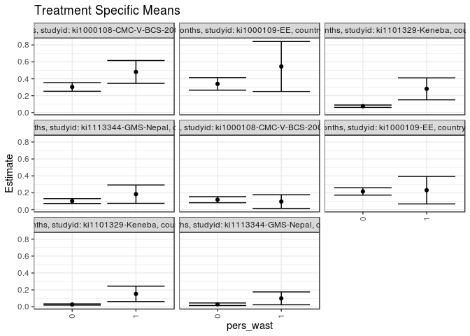

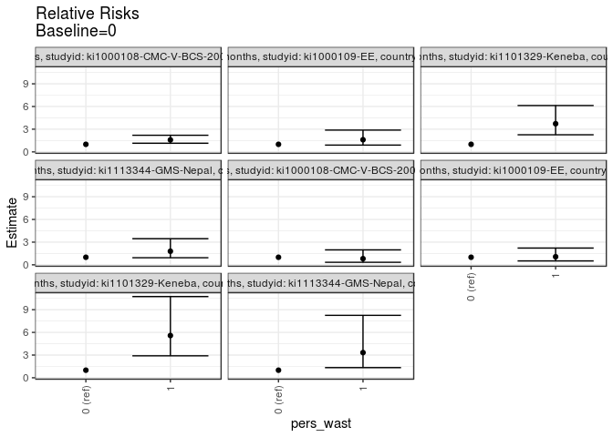

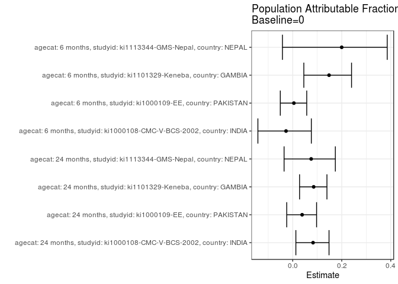

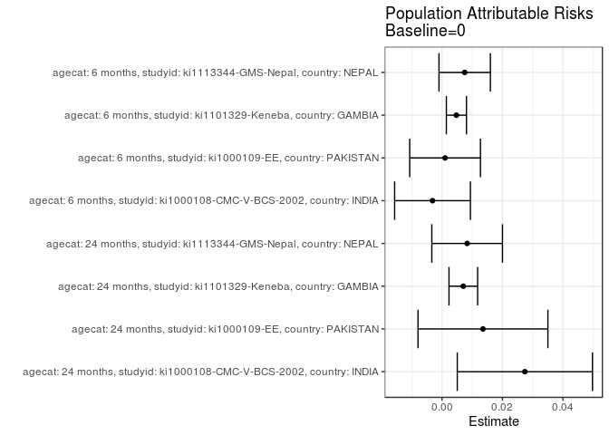

## Results Table

### Parameter: TSM

| agecat | studyid | country | intervention_level | baseline_level | estimate | ci_lower | ci_upper |
| --- | --- | --- | --- | --- | --- | --- | --- |
| 6 months | ki1000108-CMC-V-BCS-2002 | INDIA | 0 | NA | 0.1182109 | 0.0823944 | 0.1540273 |
| 6 months | ki1000108-CMC-V-BCS-2002 | INDIA | 1 | NA | 0.0961538 | 0.0159172 | 0.1763905 |
| 6 months | ki1000109-EE | PAKISTAN | 0 | NA | 0.2161383 | 0.1727721 | 0.2595046 |
| 6 months | ki1000109-EE | PAKISTAN | 1 | NA | 0.2307692 | 0.0686025 | 0.3929359 |
| 6 months | ki1101329-Keneba | GAMBIA | 0 | NA | 0.0273908 | 0.0199054 | 0.0348762 |
| 6 months | ki1101329-Keneba | GAMBIA | 1 | NA | 0.1529416 | 0.0620264 | 0.2438569 |
| 6 months | ki1113344-GMS-Nepal | NEPAL | 0 | NA | 0.0300601 | 0.0150648 | 0.0450554 |
| 6 months | ki1113344-GMS-Nepal | NEPAL | 1 | NA | 0.1000000 | 0.0240229 | 0.1759771 |
| 24 months | ki1000108-CMC-V-BCS-2002 | INDIA | 0 | NA | 0.3031685 | 0.2520108 | 0.3543261 |
| 24 months | ki1000108-CMC-V-BCS-2002 | INDIA | 1 | NA | 0.4805414 | 0.3454201 | 0.6156627 |
| 24 months | ki1000109-EE | PAKISTAN | 0 | NA | 0.3397436 | 0.2651980 | 0.4142892 |
| 24 months | ki1000109-EE | PAKISTAN | 1 | NA | 0.5454545 | 0.2503174 | 0.8405917 |
| 24 months | ki1101329-Keneba | GAMBIA | 0 | NA | 0.0754707 | 0.0615960 | 0.0893455 |
| 24 months | ki1101329-Keneba | GAMBIA | 1 | NA | 0.2810451 | 0.1506994 | 0.4113909 |
| 24 months | ki1113344-GMS-Nepal | NEPAL | 0 | NA | 0.1023256 | 0.0736495 | 0.1310016 |
| 24 months | ki1113344-GMS-Nepal | NEPAL | 1 | NA | 0.1836735 | 0.0751412 | 0.2922058 |

### Parameter: E(Y)

| agecat | studyid | country | intervention_level | baseline_level | estimate | ci_lower | ci_upper |
| --- | --- | --- | --- | --- | --- | --- | --- |
| 6 months | ki1000108-CMC-V-BCS-2002 | INDIA | NA | NA | 0.1150685 | 0.0822869 | 0.1478501 |
| 6 months | ki1000109-EE | PAKISTAN | NA | NA | 0.2171582 | 0.1752594 | 0.2590570 |
| 6 months | ki1101329-Keneba | GAMBIA | NA | NA | 0.0321560 | 0.0242153 | 0.0400968 |
| 6 months | ki1113344-GMS-Nepal | NEPAL | NA | NA | 0.0375671 | 0.0217902 | 0.0533439 |
| 24 months | ki1000108-CMC-V-BCS-2002 | INDIA | NA | NA | 0.3306011 | 0.2823401 | 0.3788621 |
| 24 months | ki1000109-EE | PAKISTAN | NA | NA | 0.3532934 | 0.2805798 | 0.4260070 |
| 24 months | ki1101329-Keneba | GAMBIA | NA | NA | 0.0825243 | 0.0683172 | 0.0967313 |
| 24 months | ki1113344-GMS-Nepal | NEPAL | NA | NA | 0.1106472 | 0.0825255 | 0.1387689 |

### Parameter: RR

| agecat | studyid | country | intervention_level | baseline_level | estimate | ci_lower | ci_upper |
| --- | --- | --- | --- | --- | --- | --- | --- |
| 6 months | ki1000108-CMC-V-BCS-2002 | INDIA | 0 | 0 | 1.0000000 | 1.0000000 | 1.000000 |
| 6 months | ki1000108-CMC-V-BCS-2002 | INDIA | 1 | 0 | 0.8134096 | 0.3347787 | 1.976336 |
| 6 months | ki1000109-EE | PAKISTAN | 0 | 0 | 1.0000000 | 1.0000000 | 1.000000 |
| 6 months | ki1000109-EE | PAKISTAN | 1 | 0 | 1.0676923 | 0.5141166 | 2.217331 |
| 6 months | ki1101329-Keneba | GAMBIA | 0 | 0 | 1.0000000 | 1.0000000 | 1.000000 |
| 6 months | ki1101329-Keneba | GAMBIA | 1 | 0 | 5.5836924 | 2.9032964 | 10.738697 |
| 6 months | ki1113344-GMS-Nepal | NEPAL | 0 | 0 | 1.0000000 | 1.0000000 | 1.000000 |
| 6 months | ki1113344-GMS-Nepal | NEPAL | 1 | 0 | 3.3266667 | 1.3405404 | 8.255410 |
| 24 months | ki1000108-CMC-V-BCS-2002 | INDIA | 0 | 0 | 1.0000000 | 1.0000000 | 1.000000 |
| 24 months | ki1000108-CMC-V-BCS-2002 | INDIA | 1 | 0 | 1.5850641 | 1.1417924 | 2.200425 |
| 24 months | ki1000109-EE | PAKISTAN | 0 | 0 | 1.0000000 | 1.0000000 | 1.000000 |
| 24 months | ki1000109-EE | PAKISTAN | 1 | 0 | 1.6054889 | 0.8954290 | 2.878614 |
| 24 months | ki1101329-Keneba | GAMBIA | 0 | 0 | 1.0000000 | 1.0000000 | 1.000000 |
| 24 months | ki1101329-Keneba | GAMBIA | 1 | 0 | 3.7238958 | 2.2612511 | 6.132623 |
| 24 months | ki1113344-GMS-Nepal | NEPAL | 0 | 0 | 1.0000000 | 1.0000000 | 1.000000 |
| 24 months | ki1113344-GMS-Nepal | NEPAL | 1 | 0 | 1.7949907 | 0.9333402 | 3.452108 |

### Parameter: PAR

| agecat | studyid | country | intervention_level | baseline_level | estimate | ci_lower | ci_upper |
| --- | --- | --- | --- | --- | --- | --- | --- |
| 6 months | ki1000108-CMC-V-BCS-2002 | INDIA | 0 | NA | -0.0031424 | -0.0156855 | 0.0094008 |
| 6 months | ki1000109-EE | PAKISTAN | 0 | NA | 0.0010198 | -0.0106873 | 0.0127270 |
| 6 months | ki1101329-Keneba | GAMBIA | 0 | NA | 0.0047653 | 0.0014406 | 0.0080900 |
| 6 months | ki1113344-GMS-Nepal | NEPAL | 0 | NA | 0.0075070 | -0.0009972 | 0.0160111 |
| 24 months | ki1000108-CMC-V-BCS-2002 | INDIA | 0 | NA | 0.0274326 | 0.0050548 | 0.0498104 |
| 24 months | ki1000109-EE | PAKISTAN | 0 | NA | 0.0135498 | -0.0079510 | 0.0350506 |
| 24 months | ki1101329-Keneba | GAMBIA | 0 | NA | 0.0070535 | 0.0023161 | 0.0117910 |
| 24 months | ki1113344-GMS-Nepal | NEPAL | 0 | NA | 0.0083216 | -0.0033726 | 0.0200158 |

### Parameter: PAF

| agecat | studyid | country | intervention_level | baseline_level | estimate | ci_lower | ci_upper |
| --- | --- | --- | --- | --- | --- | --- | --- |
| 6 months | ki1000108-CMC-V-BCS-2002 | INDIA | 0 | NA | -0.0273087 | -0.1420817 | 0.0759303 |
| 6 months | ki1000109-EE | PAKISTAN | 0 | NA | 0.0046963 | -0.0506976 | 0.0571699 |
| 6 months | ki1101329-Keneba | GAMBIA | 0 | NA | 0.1481920 | 0.0452838 | 0.2400079 |
| 6 months | ki1113344-GMS-Nepal | NEPAL | 0 | NA | 0.1998282 | -0.0419788 | 0.3855202 |
| 24 months | ki1000108-CMC-V-BCS-2002 | INDIA | 0 | NA | 0.0829780 | 0.0128470 | 0.1481267 |
| 24 months | ki1000109-EE | PAKISTAN | 0 | NA | 0.0383529 | -0.0244999 | 0.0973497 |
| 24 months | ki1101329-Keneba | GAMBIA | 0 | NA | 0.0854723 | 0.0279389 | 0.1396005 |
| 24 months | ki1113344-GMS-Nepal | NEPAL | 0 | NA | 0.0752084 | -0.0352562 | 0.1738862 |